# My SpotifyR Report

Author

Daan Kluizenaar

# Introducing: Juice WRLD

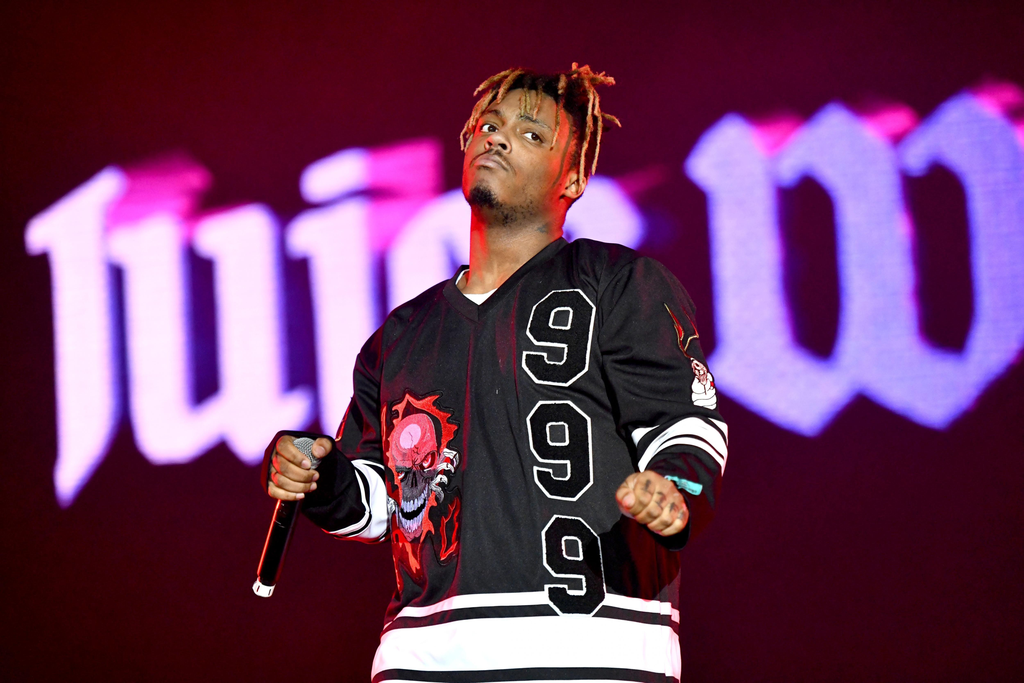

## Who is Juice WRLD?

Juice WRLD was an American rapper, singer, and songwriter from Chicago. He gained fame for his distinctive fusion of emo and rap, with his introspective lyrics, covering themes such as heartbreak and mental health, and a melodic style. His most known hits are “Lucid Dreams” and “Robbery.” He also received a lot of recognition for his impressive freestyle skills, as he freestyled all of his songs and has featured in shows where he rapped over multiple beats for more than an hour. Tragically, he passed away on December 8, 2019, at the age of 21, leaving behind a lasting impact on the music industry. In his short career of only two years (mainstream) he collaborated with artists such as Future, Travis Scott, Young Thug, and Eminem, making him one of the most prominent rappers of his generation.

### His Most Famous Line

> *“I still see your shadows in my room”*

> **- Juice WRLD in “Lucid Dreams” (2018)**

### His Albums

His debut album “Goodbye & Good Riddance” came out on streaming services in May 2018. Since then the album never left the US Billboard 200. A few months later he released together with rapper Future a collaboration album titled “Future & Juice WRLD Present… WRLD ON DRUGS”. In early 2019 he dropped his final album before he sadly past away at the end of 2019, it is called “Death Race For Love.” His latest two albums are posthumous and were released by his label. “Legends Never Die” was the first posthumous album and gained 497,000 first week sales, marking its massive success. “Fighting Demons” was released at the end of 2021. A few months later, in 2022, the deluxe version released with three new songs.

- “Goodbye & Good Riddance” (released in May 2018)
- “Future & Juice WRLD Present... WRLD ON DRUGS” (October 2018)
- “Death Race For Love (Bonus Track Version)” (2019)
- “Legends Never Die” (2020)
- “Fighting Demons (Deluxe)” (2022)

## My Favorites

### My Favorite Album

Death Race For Love (2019)

[figure not shown]

### My Favorite Song

[HeMotions (2019, YouTube link)](https://youtu.be/w53-Ts8h2eE?si=pOxPWCeh2FveQ4yT)

[video not shown]

### My Favorite Lyrics

> *Ayy, look at my bank account (You dig? Hoo)*

> *Look at the cash amount (Hoo, ooh, you dig?)*

> *I get the cash, I’m out (You dig? Yeah, hoo)*

> *I do the dash, I’m out (You dig? Yeah, hoo, ooh)*

> *Look at my bank account (You dig? Ooh)*

> *Look at the cash amount (You dig? Skrrt, uh)*

> *I get the cash, I’m out (Look, uh)*

> *I just be cashin’ out (You dig? Skrr)*

> …

> **- Juice WRLD in “Armed And Dangerous” (2018)**

# Data analysis

## Data Source

I retrieved the data from the `spotifyr` package, and stored it in my data folder.

## Import Data

I installed the necessary packages and imported the data into this program.

```r
# Necessary packages
library(ggplot2)
library(dplyr)
library(rmarkdown)
library(knitr)

#Import data into "Juice_WRLD"
library(readr)
Juice_WRLD <- read_csv("/Users/daankluizenaar/Desktop/Data Science in Health Care/SpotifyR Data Science/Juice WRLD.csv")
```

## What Does The Data Frame Look Like?

Here is a little preview of the “Juice_WRLD” dataset with five random songs.

```r
# Show five random songs from the dataset
Juice_WRLD |> dplyr::slice_sample(n=5) |> knitr::kable(digits = 2)
```

| artist_name | track_name | track_number | album_name | album_release_year | album_release_date | valence | energy | danceability | loudness | tempo | speechiness | instrumentalness | liveness | key_name | mode_name | key_mode | duration_ms |
| --- | --- | --- | --- | --- | --- | --- | --- | --- | --- | --- | --- | --- | --- | --- | --- | --- | --- |
| Juice WRLD | Feline (with Polo G & Trippie Redd) | 13 | Fighting Demons (Deluxe) | 2022 | 2022-03-18 | 0.30 | 0.62 | 0.58 | -6.66 | 110.11 | 0.32 | 0 | 0.10 | C | major | C major | 212203 |
| Juice WRLD | All Girls Are The Same | 2 | Goodbye & Good Riddance (5 Year Anniversary Edition) | 2023 | 2023-05-18 | 0.20 | 0.52 | 0.67 | -7.59 | 161.92 | 0.30 | 0 | 0.09 | C | major | C major | 165819 |
| Juice WRLD | Who Shot Cupid? | 13 | Death Race For Love (Bonus Track Version) | 2019 | 2019-03-08 | 0.59 | 0.93 | 0.76 | -2.81 | 125.99 | 0.04 | 0 | 0.10 | D# | major | D# major | 214245 |
| Juice WRLD | Go Hard 2.0 | 10 | Fighting Demons (Deluxe) | 2022 | 2022-03-18 | 0.07 | 0.46 | 0.62 | -7.67 | 145.29 | 0.18 | 0 | 0.16 | G | minor | G minor | 214727 |
| Juice WRLD | Robbery | 8 | Death Race For Love (Bonus Track Version) | 2019 | 2019-03-08 | 0.57 | 0.69 | 0.62 | -5.12 | 79.90 | 0.05 | 0 | 0.15 | D | major | D major | 240050 |

## Data Preparation

I want to remove the two albums “Goodbye & Good Riddance (5 Year Anniversary Edition)” and “Goodbye & Good Riddance (Anniversary),” because these are anniversary editions of his first album that came out in 2018 “Goodbye & Good Riddance.” If I keep all three albums, some songs will be repeated three times. Also, if I had deleted songs with the same name with the ‘distinct’ code, I would end up with the latest anniversary edition that came out five years after its original release. I want to keep the original release because it is his first studio album. Moreover, one of my favorite songs is on the original release, which I want to keep on the original album.

```r
# Remove the two 'anniversary edition' albums in order to remove duplicates
albums_to_remove <- c(
  "Goodbye & Good Riddance (5 Year Anniversary Edition)",
  "Goodbye & Good Riddance (Anniversary)"
)
Juice_WRLD <- Juice_WRLD |> filter(!(album_name %in% albums_to_remove))
```

## Album Analysis (Valence)

In this section I will analyze the valence of each album and compare the five albums, using a boxplot for visualization. Valence is a measurement from 0 to 1.0 that describes the positiveness conveyed in a song. The most prominent changes I will make to the boxplot is abbreviating the album names on the x-axis to minimize space, and changing the colors of the albums in the plot to the colors that match the best with the color palette of the album.

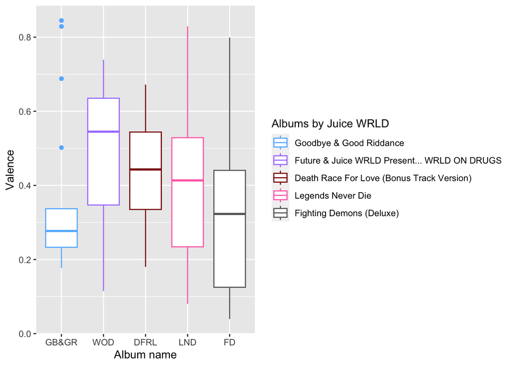

```r
# Change album_name from character to factor, and order the albums on the x-axis manually (I ordered the names by release year)
Juice_WRLD$album_name <- factor(Juice_WRLD$album_name, levels = c("Goodbye & Good Riddance", "Future & Juice WRLD Present... WRLD ON DRUGS", "Death Race For Love (Bonus Track Version)", "Legends Never Die", "Fighting Demons (Deluxe)"))

# Create a custom name for album names because otherwise the boxplot labels are unreadable
custom_album_names <- c("GB&GR", "WOD", "DFRL", "LND", "FD")

# Change colors for each album to match it with the album cover colors
custom_colors <- c("steelblue1", "mediumpurple1", "darkred", "hotpink1", "grey40")

# Plot a boxplot
ggplot(Juice_WRLD, aes(x=album_name, y=valence, color=album_name))+
  geom_boxplot()+
  labs(x="Album name", y="Valence") +
  scale_x_discrete(labels = custom_album_names)+
  scale_color_manual(values = setNames(custom_colors, levels(Juice_WRLD$album_name)), name = "Albums by Juice WRLD")
```

When analyzing the valence among each Juice WRLD album, we can see that ‘Goodbye & Good Riddance’ has the lowest medium and is the ‘saddest’ album. However, this album also has a lot of outliers, of which one is his most ‘positive’ song, which I will reveal later.

We can also see here that his latest two albums have the most range in valence. Both albums have a large range of sad and positive songs.

WRLD ON DRUGS has the highest medium, so we can say it is Juice’s most positive album from his discography.

Overall, his albums are rather sad since most mediums are below 0.5.

## Album Analysis (Danceability)

In this section I will do the exact same as the last one. However, I will replace the ‘valence’ variable with the ‘danceability’ variable. I want to measure the danceability of each album and compare the albums to each other. Danceability is a measurement from 0 to 1.0 describing how danceable a song is.

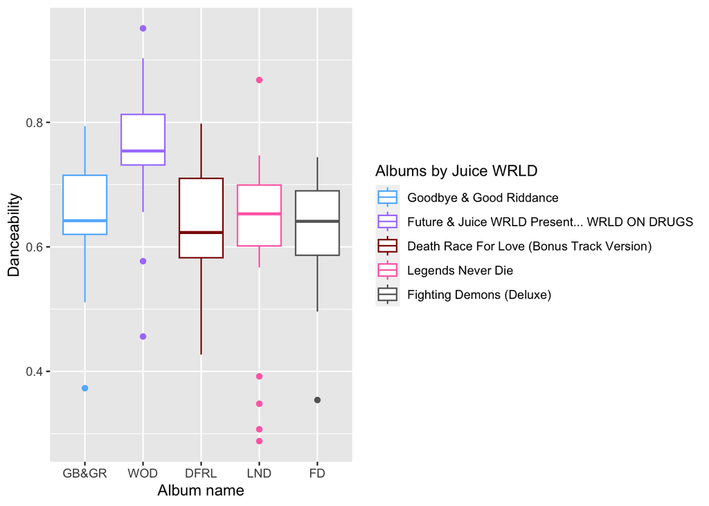

```r
# Change album_name from character to factor, and order the albums on the x-axis manually (I ordered the names by release year)
Juice_WRLD$album_name <- factor(Juice_WRLD$album_name, levels = c("Goodbye & Good Riddance", "Future & Juice WRLD Present... WRLD ON DRUGS", "Death Race For Love (Bonus Track Version)", "Legends Never Die", "Fighting Demons (Deluxe)"))

# Create a custom name for album names because otherwise the boxplot labels are unreadable
custom_album_names <- c("GB&GR", "WOD", "DFRL", "LND", "FD")

# Change colors for each album to match it with the album cover colors
custom_colors <- c("steelblue1", "mediumpurple1", "darkred", "hotpink1", "grey40")

# Plot a boxplot
ggplot(Juice_WRLD, aes(x=album_name, y=danceability, color=album_name))+
  geom_boxplot()+
  labs(x="Album name", y="Danceability") +
  scale_x_discrete(labels = custom_album_names)+
  scale_color_manual(values = setNames(custom_colors, levels(Juice_WRLD$album_name)), name = "Albums by Juice WRLD")
```

For danceability, WRLD ON DRUGS has (again) the highest medium and is therefore the most danceable album.

Goodbye and Good Riddance is the saddest album, but it is still rather danceable.

Overall, even though Juice WRLD makes very sad albums, they are quite danceable. Does that mean that Juice made sad albums for people to dance on?

## Juice WRLD’s Most Positive Song

Juice WRLD is famous for his sad and introspective songs. Therefore, I would like to find out his most positive song. I will list Juice WRLD’s top five releases with the highest valence.

```r
# The top five releases with the most valence
Juice_WRLD |> slice_max(valence, n=5) |> dplyr::select(track_name, album_name, album_release_year, valence) |> knitr::kable(digits = 2)
```

| track_name | album_name | album_release_year | valence |
| --- | --- | --- | --- |
| Armed And Dangerous | Goodbye & Good Riddance | 2018 | 0.84 |
| Intro | Goodbye & Good Riddance | 2018 | 0.83 |
| The Man, The Myth, The Legend - Interlude | Legends Never Die | 2020 | 0.83 |
| Juice WRLD Speaks | Fighting Demons (Deluxe) | 2022 | 0.80 |
| Make It Back | Future & Juice WRLD Present… WRLD ON DRUGS | 2018 | 0.74 |

Armed And Dangerous is Juice WRLD most positive song. However, the following three releases are interludes or skits… I would like to filter these out.

```r
# Filter out the skits and interludes
Juice_WRLD |> filter(!track_name %in% c("Intro", "The Man, The Myth, The Legend - Interlude", "Juice WRLD Speaks", "Karma - Skit")) |> slice_max(valence, n=5) |> dplyr::select(track_name, album_name, album_release_year, valence) |> knitr::kable(digits = 2)
```

| track_name | album_name | album_release_year | valence |
| --- | --- | --- | --- |
| Armed And Dangerous | Goodbye & Good Riddance | 2018 | 0.84 |
| Make It Back | Future & Juice WRLD Present… WRLD ON DRUGS | 2018 | 0.74 |
| Astronauts | Future & Juice WRLD Present… WRLD ON DRUGS | 2018 | 0.73 |
| No Issue | Future & Juice WRLD Present… WRLD ON DRUGS | 2018 | 0.72 |
| Different (feat. Yung Bans) | Future & Juice WRLD Present… WRLD ON DRUGS | 2018 | 0.68 |

So, here I have listed the top 5 Juice WRLD songs with the most valence, excluding the interludes and skits.

His album ‘WRLD ON DRUGS’ dominates this list. But that is no surprise, since this album is also the most positive album (as we saw in the boxplot above).

Still, I want to narrow this list down a bit more. WRLD ON DRUGS is a collaboration with rapper Future, so four out of five songs on this list are not solely him. Also, making an album with another artist can have influence on your own style when working on the album.

```r
# Filter out the collaboration album
Juice_WRLD |> filter(!track_name %in% c("Intro", "The Man, The Myth, The Legend - Interlude", "Juice WRLD Speaks", "Karma - Skit", "Eminem Speaks") & album_name != "Future & Juice WRLD Present... WRLD ON DRUGS") |> slice_max(valence, n=5) |> dplyr::select(track_name, album_name, album_release_year, valence) |> knitr::kable(digits = 2)
```

| track_name | album_name | album_release_year | valence |
| --- | --- | --- | --- |
| Armed And Dangerous | Goodbye & Good Riddance | 2018 | 0.84 |
| Make Believe | Death Race For Love (Bonus Track Version) | 2019 | 0.67 |
| Won’t Let Go | Death Race For Love (Bonus Track Version) | 2019 | 0.65 |
| Hate The Other Side (with Marshmello & The Kid Laroi) | Legends Never Die | 2020 | 0.65 |
| Ring Ring (with Rvssian feat. Clever) | Death Race For Love (Bonus Track Version) | 2019 | 0.62 |

There we go! Juice WRLD’s most positive songs that were made with him as the lead artist.

Here we see that the album ‘Death Race For Love’ is dominating the list, which makes sense since this album is the second most positive album of Juice WRLD after WRLD ON DRUGS (based on where the medium is in the boxplot).

Armed And Dangerous is still Juice’s most positive song. Do we agree?

[video not shown]

## Juice WRLD’s Saddest Song

After determining his most positive song, I thought it would be interesting to get to know his saddest song. As I said before, he sure is famous for his emotional/sad songs. This time, I will list Juice WRLD’s top five releases with the lowest valence.

```r
# The top five saddest releases
Juice_WRLD |> slice_min(valence, n=5) |> dplyr::select(track_name, album_name, album_release_year, valence) |> knitr::kable(digits = 2)
```

| track_name | album_name | album_release_year | valence |
| --- | --- | --- | --- |
| Burn | Fighting Demons (Deluxe) | 2022 | 0.04 |
| Go Hard | Fighting Demons (Deluxe) | 2022 | 0.05 |
| Go Hard 2.0 | Fighting Demons (Deluxe) | 2022 | 0.07 |
| Sometimes | Fighting Demons (Deluxe) | 2022 | 0.08 |
| Wishing Well | Legends Never Die | 2020 | 0.08 |

This time no skits or interludes in the list, therefore we do not have to filter any of these out!

‘Burn’ is Juice WRLD’s saddest song, with a valence of 0.04.

‘Fighting Demons’ is his second saddest album (as we saw above in the boxplot) but has the widest range, so it is no surprise that songs from this album are dominating this list.

I thought it was also quite interesting to see the difference in valence between ‘Go Hard’ and ‘Go Hard 2.0.’ The latter is a second version of the song as it features an additional verse from Juice himself. Apparently, this extra verse makes the song overall slightly more positive, with 0.02 more valence.

## Juice WRLD’s Most Danceable Song

For the last section of the analysis of Juice WRLD’s discography, I would like to know his most danceable song. I think this would be interesting to find out, since, as I said multiple times before, he is famous for his sad and emotional songs.

```r
# The top five most danceable songs
Juice_WRLD |> slice_max(danceability, n=5) |> dplyr::select(track_name, album_name, album_release_year, danceability) |> knitr::kable(digits = 2)
```

| track_name | album_name | album_release_year | danceability |
| --- | --- | --- | --- |
| 7 Am Freestyle | Future & Juice WRLD Present… WRLD ON DRUGS | 2018 | 0.95 |
| Red Bentley (feat. Young Thug) | Future & Juice WRLD Present… WRLD ON DRUGS | 2018 | 0.90 |
| Blood On My Jeans | Legends Never Die | 2020 | 0.87 |
| WRLD On Drugs | Future & Juice WRLD Present… WRLD ON DRUGS | 2018 | 0.82 |
| No Issue | Future & Juice WRLD Present… WRLD ON DRUGS | 2018 | 0.82 |

Future and Juice WRLD’s collaboration album is (again) the most dominant album in this list. We can also see this in the boxplot above. However, I would like to determine the danceability of Juice WRLD’s solo work:

```r
# Filter out the collaboration album
Juice_WRLD |> slice_max(danceability, n=12) |> filter(album_name != "Future & Juice WRLD Present... WRLD ON DRUGS") |> dplyr::select(track_name, album_name, album_release_year, danceability) |> knitr::kable(digits = 2)
```

| track_name | album_name | album_release_year | danceability |
| --- | --- | --- | --- |
| Blood On My Jeans | Legends Never Die | 2020 | 0.87 |
| ON GOD (feat. Young Thug) | Death Race For Love (Bonus Track Version) | 2019 | 0.80 |
| Long Gone | Goodbye & Good Riddance | 2018 | 0.79 |
| Syphilis | Death Race For Love (Bonus Track Version) | 2019 | 0.78 |
| Black & White | Goodbye & Good Riddance | 2018 | 0.78 |

Here we go! ‘Blood On My Jeans’ is his most danceable solo song.

[video not shown]